# scRNA-seq

Noelle Wheeler

2023-03-20

#### Read count matrix into R

```r
library(magrittr)
library(readr)
library(tibble)
library(Matrix)
load_counts_matrix <- function (file, FEATURE_COL="GENE", AS_SPARSE=TRUE) {
    read_tsv(file) %>%
        column_to_rownames(FEATURE_COL) %>%
        as.matrix %>% Matrix(sparse=AS_SPARSE)
}
```

```r
sparse_matrix <- load_counts_matrix("WT-1.dge.txt")
dense_matrix <- load_counts_matrix("WT-1.dge.txt", AS_SPARSE=FALSE)
```

#### Compare the sizes of the two

```r
format(object.size(sparse_matrix), units = "Mb")
```

```
## [1] "24.3 Mb"
```

```r
format(object.size(dense_matrix), units = "Mb")
```

```
## [1] "272.2 Mb"
```

#### Construct a SingleCellExperiment

```r
# BiocManager::install('SingleCellExperiment')
library(SingleCellExperiment)
sce <- SingleCellExperiment(assays = list(counts = sparse_matrix))

options(width = 60, max.print = 20)
head(assay(sce, "counts"))
```

```
## 6 x 1400 sparse Matrix of class "dgCMatrix"
##
## A1BG     . . . . . . . . . . . . . . . . . . . . . . . . ......
## A1BG-AS1 . . . . . . . . . . . . . . . . . . . . 1 . . . ......
##
##  ..............................
##  ........suppressing 1376 columns and 2 rows in show(); maybe adjust 'options(max.print= *, width = *)'
##  ..............................
##
## A2ML1-AS2 . . . . . . . . . . . . . . . . . . . . . . . . ......
## A4GALT    . . . . . . . . . . 3 . . . . . . . . . . . . . ......
```

#### How many total UMIs were found in each of the first five cells?

```r
counts_matrix <- counts(sce)
```

```r
# sum first five columns
total_UMI <- c()
for (i in seq(1:5)){
  total_UMI <- append(total_UMI, sum(counts_matrix[,i]))
}
total_UMI
```

```
## [1] 42572 33667 30704 28555 25858
```

#### How many genes are detected in each of the first five cells?

```r
# find number of non-zero entries in first five columns
num_genes <- c()
for (i in seq(1:5)){
  num_genes <- append(num_genes, sum(counts_matrix[,i] != 0))
}
num_genes
```

```
## [1] 7416 7092 6815 6216 6166
```

#### How many genes have non-zero counts in any of the first five cells?

```r
num_genes_first_five <- sum(counts_matrix[, seq(1:5)] != 0)
num_genes_first_five
```

```
## [1] 33705
```

#### If you were to change the row- and column-names of the original matrix, how could you keep track of the original names?

The original row- and column-names are stored in the rownames and colnames attributes. This can be accessed using ‘rownames(sce)’ and ‘colnames(sce)’.

#### Following the Quality Control chapter, add QC metrics to the SingleCellExperiment object

```r
# BiocManager::install(c('scuttle', 'scran', 'scater', 'uwot', 'rtracklayer'))
library(scuttle)
MT_names <- grep("^MT-", rownames(sce), value = T)
is_mito <- rownames(sce) %in% MT_names
# add qc metrics to current sce
sce <- addPerCellQCMetrics(sce, subsets=list(Mito=is_mito))
# head(sce_cell)
colnames(colData(sce))
```

```
## [1] "sum"                   "detected"
## [3] "subsets_Mito_sum"      "subsets_Mito_detected"
## [5] "subsets_Mito_percent"  "total"
```

```r
# add qc metrics to new df called, df to use later
df <- perCellQCMetrics(sce, subsets=list(Mito=is_mito))
```

#### Generate a plot of each (a) the total number of UMI counts per cell and (b) the total number of expressed genes per cell

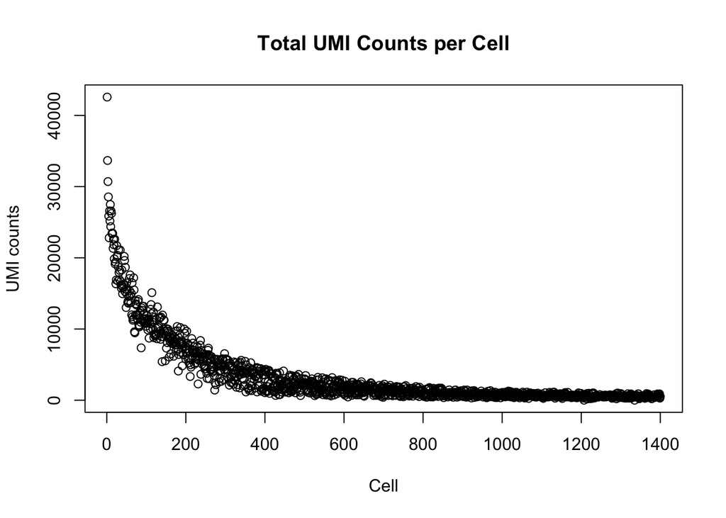

```r
col_data <- colData(sce)
# total number of UMI counts per cell
plot(col_data$sum, main = "Total UMI Counts per Cell", xlab = "Cell", ylab = "UMI counts")
```

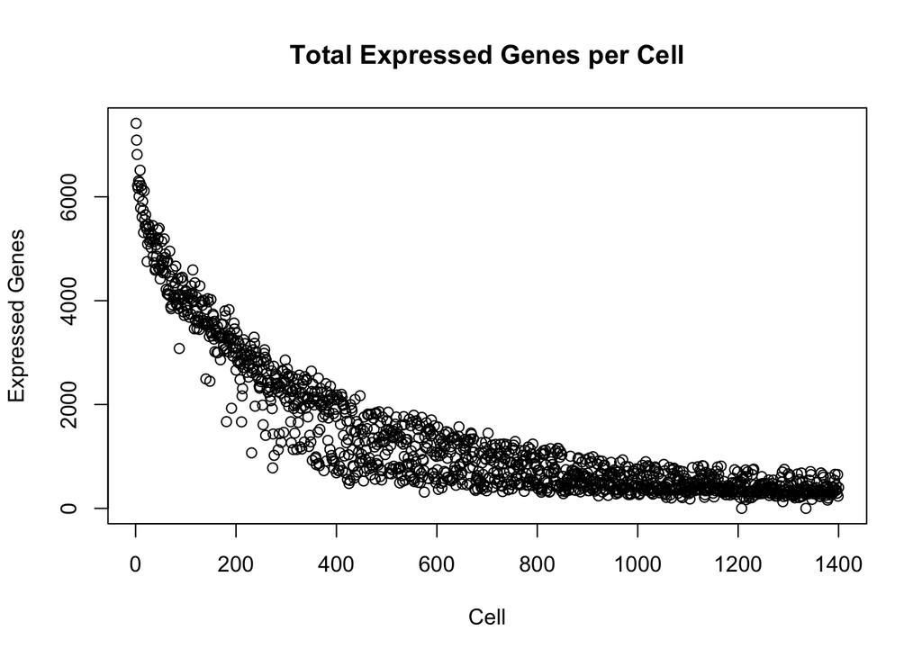

```r
# total number of expressed genes per cell
plot(col_data$detected, main = "Total Expressed Genes per Cell", xlab = "Cell", ylab = "Expressed Genes")
```

These plots show that some cells have a large number of expressed genes and UMIs. For total UMI this number decreases quickly and remains at or close to zero for most cells. For expressed genes it decreases slower and less than half the cells have expressed genes at or close to zero. This means that most of the genes in cells are lowly expressed and that the expressed genes show different isoforms, which is what we expect to see.

#### Generate a plot for percent mitochondrial reads

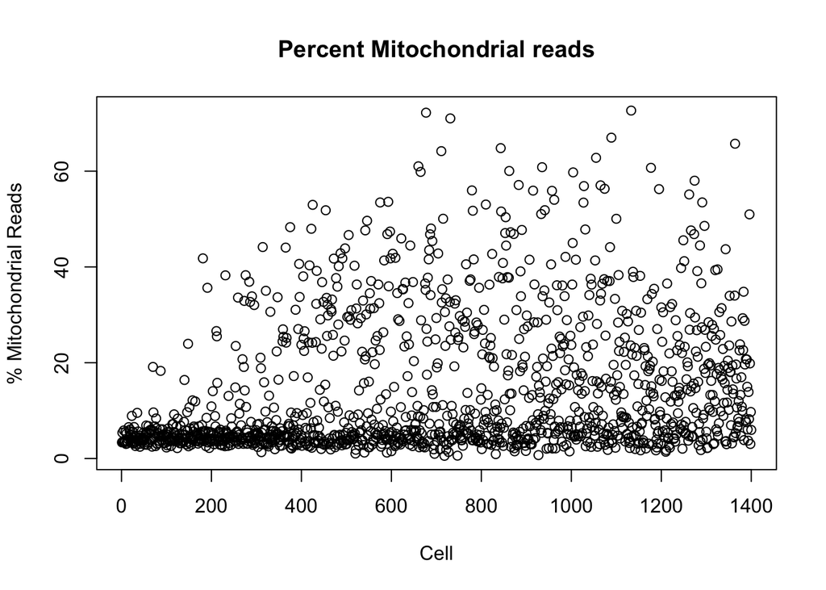

```r
plot(col_data$subsets_Mito_percent, main = "Percent Mitochondrial reads", xlab = "Cell", ylab = "% Mitochondrial Reads")
```

#### Decide on some threshold for either QC parameter and remove the corresponding cells

```r
# remove cells if they have a library size below 10,000
qc.lib <- df$sum < 1e4
discard <- qc.lib
DataFrame(LibSize=sum(qc.lib))
```

```
## DataFrame with 1 row and 1 column
##     LibSize
##   <integer>
## 1      1273
```

```r
# identify cells that are outliers for the sum QC metric
reasons <- perCellQCFilters(sce,
    sub.fields=c("sum"))
colSums(as.matrix(reasons))
```

```
##   low_lib_size low_n_features       high_sum        discard
##              2              2            297            299
```

```r
summary(reasons$discard)
```

```
##    Mode   FALSE    TRUE
## logical    1101     299
```

```r
# remove the low quality cells
filtered <- sce[,!reasons$discard]
```

#### Normalize the counts via deconvolution

```r
library(scran)
set.seed(100)
clust <- quickCluster(filtered)
table(clust)
```

```
## clust
##   1   2   3   4   5   6
## 212 179 263 123 134 190
```

```r
deconv_sf <- calculateSumFactors(filtered, cluster=clust)
summary(deconv_sf)
```

```
##    Min. 1st Qu.  Median    Mean 3rd Qu.    Max.
##  0.1252  0.4086  0.6830  1.0000  1.3033  3.8762
```

#### Do the size factors calculated by computeSumFactors show the expected behavior?

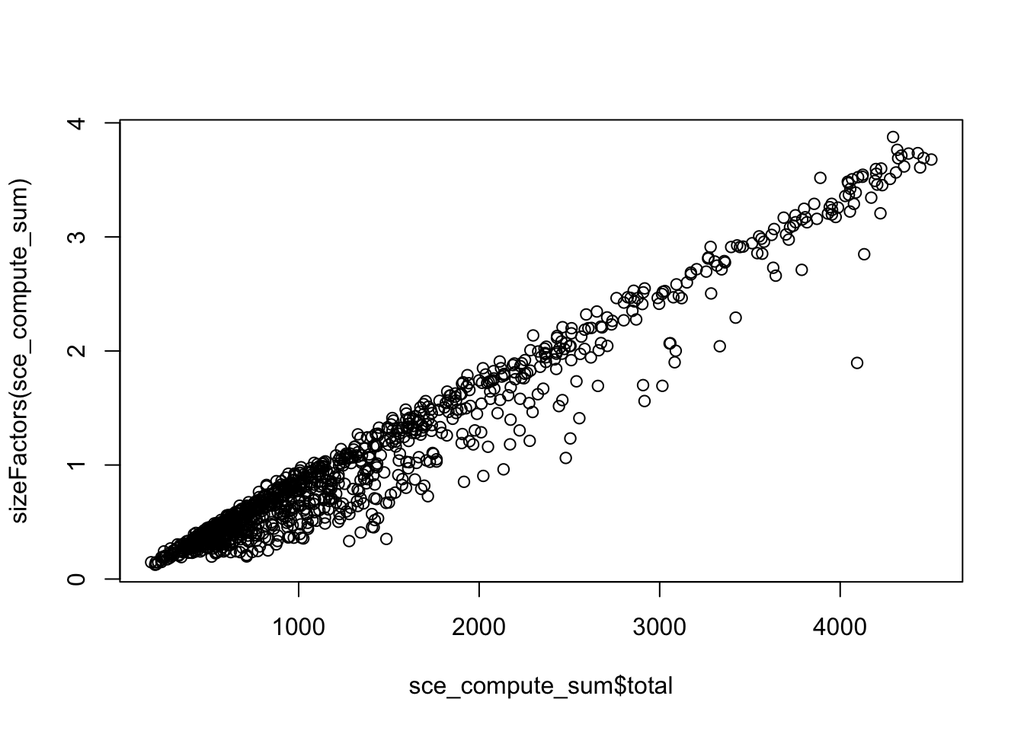

```r
sce_compute_sum <- computeSumFactors(filtered, cluster=clust, min.mean=0.1)
plot(sce_compute_sum$total, sizeFactors(sce_compute_sum))
```

```r
sce_compute_sum <- logNormCounts(sce_compute_sum)
```

Yes, it shows expected behavior that is a linear correlation.

#### What type of cells?

```r
# assign cell labels using reference data
# BiocManager::install('celldex')
# BiocManager::install('SingleR')
library(celldex)
ref <- BlueprintEncodeData()
ref
```

```
## class: SummarizedExperiment
## dim: 19859 259
## metadata(0):
## assays(1): logcounts
## rownames(19859): TSPAN6 TNMD ... LINC00550
##   GIMAP1-GIMAP5
## rowData names(0):
## colnames(259): mature.neutrophil
##   CD14.positive..CD16.negative.classical.monocyte ...
##   epithelial.cell.of.umbilical.artery.1
##   dermis.lymphatic.vessel.endothelial.cell.1
## colData names(3): label.main label.fine label.ont
```

```r
library(SingleR)
pred <- SingleR(test=sce_compute_sum, ref=ref, labels=ref$label.main)
table(pred$labels)
```

```
##
##        Adipocytes        Astrocytes      Chondrocytes
##                 2                48                 2
## Endothelial cells  Epithelial cells      Erythrocytes
##                59               421               125
##       Fibroblasts               HSC     Keratinocytes
##                23                 9                30
##       Melanocytes   Mesangial cells          Myocytes
##                19               254                33
##           Neurons         Pericytes   Skeletal muscle
##                 6                57                 1
##     Smooth muscle
##                12
```

It seems like these are kidney cells because Endothelial cells, Mesangial cells, and Epithelial cells, which are some of the most common cells, are found in the kidney.